# Lab 6: CNNs

Ryan Schaefer

```python
import numpy as np
import os
import cv2
import copy
import sys
import pandas as pd
import matplotlib.pyplot as plt
import seaborn as sns
from statsmodels.stats.contingency_tables import mcnemar
from sklearn import metrics as mt
from sklearn.model_selection import RepeatedStratifiedKFold
import tensorflow as tf
from tensorflow import keras
from tensorflow.keras.metrics import Recall
from tensorflow.keras.utils import FeatureSpace, plot_model
from tensorflow.keras.layers import Dense, Dropout, Activation, Flatten, Conv2D, MaxPooling2D, RandomBrightness
from tensorflow.keras.models import Sequential
from tensorflow.keras.applications.resnet50 import ResNet50

tf.random.set_seed(7324)
np.random.seed(7324)
```

# Data Preparation

This dataset contains x-rays of pediatric patients aged 1-5 years old from the Guangzhou Women and Children's Medical Center in Guangzhou, China. The x-rays are either labeled as having pneumonia or not having pneumonia (normal). A machine learning model on this dataset could be used to screen patients for pneumonia prior to seeing a medical professional. This could help reduce the number of patients the doctors have to see about pneumonia.

Link to dataset: https://www.kaggle.com/datasets/tolgadincer/labeled-chest-xray-images

## Load Data

```python
%%time

# Directory containing images data
data_dir = "../Datasets/chest_xray/train"
# Subdirectories with normal and pneumonia images
categories = ["NORMAL", "PNEUMONIA"]
# Size to resize images to
size = (50, 50)

labels = []
labels_binary = []
images = []
for i, cat in enumerate(categories):
    # For each label, create path to subdirectory
    path = os.path.join(data_dir, cat)
    for file in os.listdir(path):
        # Read and resize all images in subdirectory
        labels.append(cat)
        labels_binary.append(i)
        img = cv2.imread(os.path.join(path, file), cv2.IMREAD_GRAYSCALE)
        img = cv2.resize(img, size)
        images.append(img)

labels_binary = list(np.argmax(keras.utils.to_categorical(labels_binary, 2), axis = 1))
```

```
CPU times: user 13.6 s, sys: 1.49 s, total: 15.1 s
Wall time: 16.8 s
```

## Data Summary

```python
sample_size = len(images)
n_samples, n_features = np.array(images).flatten().reshape(sample_size, size[0] * size[1]).shape
h, w = size
classes = categories
n_classes = len(classes)

print(np.sum(~np.isfinite(images)))
print("n_samples: {}".format(n_samples))
print("n_features: {}".format(n_features))
print("n_classes: {}".format(n_classes))
print("classes: {}".format(classes))
print("Image Sizes {} by {}".format(h,w))
print (h * w) # the size of the images are the size of the feature vectors
```

```
0
n_samples: 5232
n_features: 2500
n_classes: 2
classes: ['NORMAL', 'PNEUMONIA']
Image Sizes 50 by 50
2500
```

## Visualize Images

```python
# a helper plotting function
def plot_gallery(images, titles, h, w, n_row=3, n_col=6):
    """Helper function to plot a gallery of portraits"""
    plt.figure(figsize=(1.7 * n_col, 2.3 * n_row))
    plt.subplots_adjust(bottom=0, left=.01, right=.99, top=.90, hspace=.35)
    for i in range(n_row * n_col):
        plt.subplot(n_row, n_col, i + 1)
        plt.imshow(images[i].reshape((h, w)), cmap=plt.cm.gray)
        plt.title(titles[i], size=12)
        plt.xticks(())
        plt.yticks(())
```

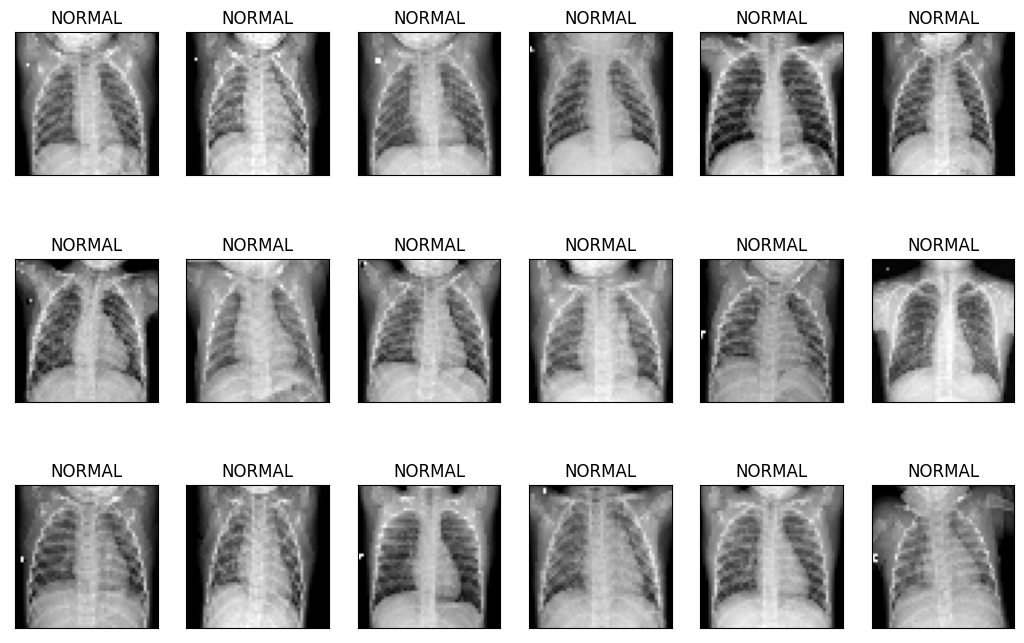

```python
# Get the index of the first pneumonia image and only display normal images
pneum_index = list(labels).index("PNEUMONIA")

plot_gallery(images[:pneum_index], labels[:pneum_index], h, w) # defaults to showing a 3 by 6 subset of the faces
```

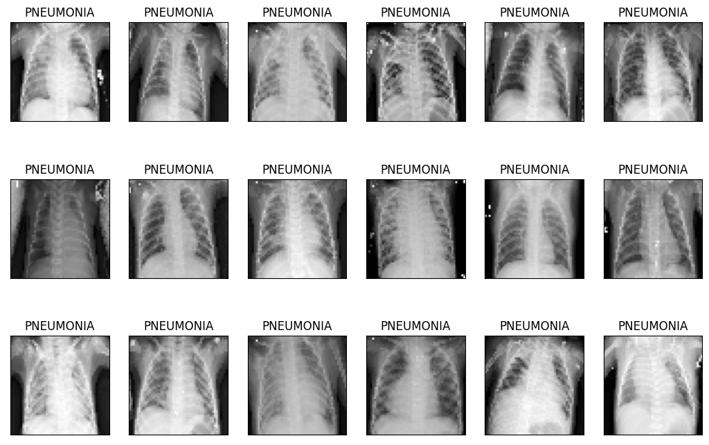

```python
# Only display pneumonia images
plot_gallery(images[pneum_index:], labels[pneum_index:], h, w) # defaults to showing a 3 by 6 subset of the faces
```

Looking at the images above, the brightness of the x-rays appears to vary from image to image. To account for this in our modeling, we will add a random brightness augmentation to the model training.

## Class Balance

```python
display(pd.Series.value_counts(labels))
pd.Series.value_counts(labels) / len(labels)
```

```
PNEUMONIA    3883
NORMAL       1349
dtype: int64
```

```
PNEUMONIA    0.742164
NORMAL       0.257836
dtype: float64
```

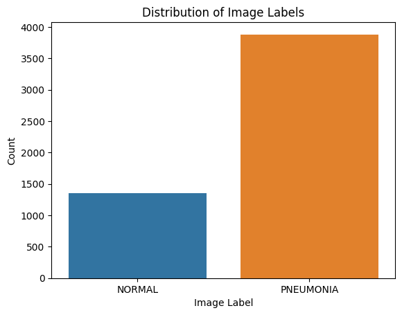

```python
df = pd.DataFrame({
    "class": labels
})

sns.countplot(data = df, x = "class")

plt.title("Distribution of Image Labels")
plt.xlabel("Image Label")
plt.ylabel("Count")

plt.show()
```

The bar graph above shows that far more patients have pneumonia than do not have pneumonia (approximately 74% with pneumonia and 26% normal). We will attempt to correct for this class imbalance when making our training/testing splits.

## Evaluation Criteria

In this business case, where a positive outcome is having pneumonia, it is much more important to minimize false negatives than false positives. If there is a false positive, someone will see a doctor but would not receive treatment after the doctor diagnoses them. Very little harm is done in this case, except for wasting a little bit of the doctor and patient's time. If there is a false negative, someone who has pneumonia will not receive the treatment that they need. To prioritize minimizing false negatives, we will use recall as our evalutation criteria.

## Training/Testing Split

We can use K-Fold cross validation with 10 folds so that every instance is used in both the training and testing sets and give us a 90/10 training/testing split in every set. To account for the potential noise in a single K-Fold run, we will use 3 repeats. To maintain the relative class frequency in the testing data, we will stratify the folds by the outcome and then oversample the training data in each split. Oversampling the training data in each split will prevent the model from prioritizing one class over another, but maintaining the relative class frequencies in the testing data will make sure the model evaluation is similar to what a deployed model will see with new data.

```python
cv = RepeatedStratifiedKFold(n_splits = 10, n_repeats = 3, random_state = 7324)
data_split = []
y_test_folds = []
y_test = []
for train, test in cv.split(images, labels_binary):
    train_norm = list(train[train < pneum_index])
    train_pneum = list(train[train >= pneum_index])
    indices = np.random.randint(len(train_norm), size = len(train_pneum) - len(train_norm))
    for i in indices:
        train_norm.append(i)

    train_indices = train_norm + train_pneum
    data_split.append((
        (np.array(images)[train_indices], np.array(labels_binary)[train_indices]),
        (np.array(images)[test], np.array(labels_binary)[test])
    ))

    y_test_folds.append(np.array(labels_binary)[test])
    for label in np.array(labels_binary)[test]:
        y_test.append(label)
```

# Modeling

## Model 1 (Architecture 1, Parameter Set 1)

```python
def create_model(num_filter_layers, kernel_size, pool_size, neurons = []):
    cnn = Sequential()

    cnn.add(RandomBrightness(factor = 0.1))

    for num_filters in num_filter_layers:
        cnn.add(
            Conv2D(
                filters=num_filters,
                kernel_size=kernel_size,
                padding='same'
            )
        )
        cnn.add(Activation('relu'))
        cnn.add(MaxPooling2D(pool_size=pool_size))

    # add one layer on flattened output
    cnn.add(Flatten())
    for n in neurons:
        cnn.add(Dense(n, activation = "relu"))
    cnn.add(Dense(1, activation = "sigmoid"))

    # Let's train the model
    cnn.compile(
        loss='binary_crossentropy',
        optimizer='rmsprop',
        metrics=[Recall(name = "recall")]
    )

    input_shape = [None, h, w, 1]
    cnn.build(input_shape)

    return cnn
```

Our first CNN architecture has 2 convolutional layers and only 1 dense layer with a sigmoid activation at the end with a single neuron for the binary classification. Each convolutional layer has 16 filters.

```python
cnn_arch1_param1 = create_model([16, 16], (3, 3), (3, 3))

cnn_arch1_param1.summary()
```

```
Model: "sequential"
_________________________________________________________________
 Layer (type)                Output Shape              Param #
=================================================================
 random_brightness (RandomB  (None, 50, 50, 1)         0
 rightness)

 conv2d (Conv2D)             (None, 50, 50, 16)        160

 activation (Activation)     (None, 50, 50, 16)        0

 max_pooling2d (MaxPooling2  (None, 16, 16, 16)        0
 D)

 conv2d_1 (Conv2D)           (None, 16, 16, 16)        2320

 activation_1 (Activation)   (None, 16, 16, 16)        0

 max_pooling2d_1 (MaxPoolin  (None, 5, 5, 16)          0
 g2D)

 flatten (Flatten)           (None, 400)               0

 dense (Dense)               (None, 1)                 401

=================================================================
Total params: 2881 (11.25 KB)
Trainable params: 2881 (11.25 KB)
Non-trainable params: 0 (0.00 Byte)
_________________________________________________________________
```

```python
plot_model(
    cnn_arch1_param1, to_file='cnn_arch1_param1.png', show_shapes=True, show_layer_names=True,
    rankdir='LR', expand_nested=False, dpi=96
)
```

[figure not shown]

```python
%%time

yhat_proba_arch1_param1_folds = []
history_arch1_param1 = {
    "recall": [],
    "val_recall": [],
    "loss": [],
    "val_loss": []
}

# Iterate through cross validation folds
for i, (train, test) in enumerate(data_split):
    # Print fold number
    sys.stderr.write('\rRepeat: {}/{}, Fold: {}/{} '.format(int(i / 10) + 1, 3, (i % 10) + 1, 10))
    sys.stderr.flush()

    # Fit model
    history = cnn_arch1_param1.fit(
        train[0],
        train[1],
        batch_size=32,
        epochs=15,
        shuffle=True,
        verbose=0,
        validation_data=(test[0], test[1])
    )

    # Store model history
    history_arch1_param1["recall"].append(history.history["recall"])
    history_arch1_param1["val_recall"].append(history.history["val_recall"])
    history_arch1_param1["loss"].append(history.history["loss"])
    history_arch1_param1["val_loss"].append(history.history["val_loss"])

    # Store model predicted probabilities
    yhat_proba_arch1_param1_folds.append(cnn_arch1_param1.predict(test[0], verbose = 0))

# Merge predicted probabilities for all folds
yhat_proba_arch1_param1 = [ prob[0] for probs in yhat_proba_arch1_param1_folds for prob in probs ]
yhat_arch1_param1 = np.round(yhat_proba_arch1_param1) # round to get binary class
yhat_arch1_param1_folds = list(map(lambda x: np.round(x)[:,0], yhat_proba_arch1_param1_folds))
# Take the mean of all history values for each epoch
for key in history_arch1_param1.keys():
    history_arch1_param1[key] = np.mean(history_arch1_param1[key], axis = 0)
```

```
Repeat: 3/3, Fold: 10/10
```

```
CPU times: user 36min 38s, sys: 8min 16s, total: 44min 55s
Wall time: 7min 46s
```

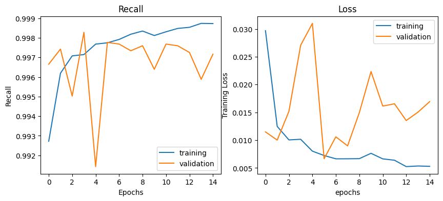

```python
plt.figure(figsize=(10,4))
plt.subplot(1,2,1)
plt.plot(history_arch1_param1['recall'], label='training')

plt.ylabel('Recall')
plt.title('Training')
plt.plot(history_arch1_param1['val_recall'], label='validation')
plt.xlabel('Epochs')
plt.title('Recall')
plt.legend()

plt.subplot(1,2,2)
plt.plot(history_arch1_param1['loss'], label='training')
plt.ylabel('Training Loss')
plt.xlabel('Epochs')

plt.plot(history_arch1_param1['val_loss'], label='validation')
plt.xlabel('epochs')
plt.title('Loss')
plt.legend()
plt.show()
```

The loss function on the training data has mostly converged, but there is a lot of variance in the loss function of the validation data. This makes it difficult to tell if the model has fully converged or not.

```python
def compare_models(y, yhat):
    num_models = len(yhat)
    if num_models > 2:
        num_rows = 2
        plt.figure(figsize = (15, 10))
    else:
        num_rows = 1
        plt.figure(figsize = (15, 5))
    num_cols = num_models // num_rows
    if num_rows * num_cols < num_models:
        num_cols += 1
    for i in range(num_models):
        acc = mt.accuracy_score(y, yhat[i])
        recall = mt.recall_score(y, yhat[i])
        plt.subplot(num_rows, num_cols, i+1)
        cm = mt.confusion_matrix(y, yhat[i])
        cm = cm / np.sum(cm, axis=1)[:, np.newaxis]
        sns.heatmap(cm, annot=True, fmt='.4f', xticklabels=categories, yticklabels=categories)
        plt.title(f'Model {i+1}: Accuracy = {acc:.4f}, Recall = {recall:.4f}')
        plt.xlabel("Predicted Class")
        plt.ylabel("Actual Class")
```

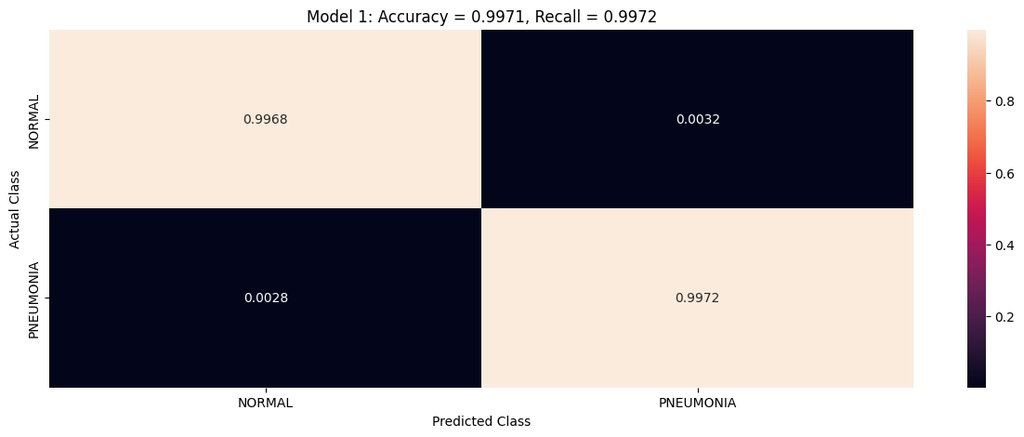

```python
compare_models(y_test, [yhat_arch1_param1])
```

## Model 2 (Architecture 2, Parameter Set 1)

The 2 CNN architecture has 3 convolutional layers instead of 2 and has 2 additional dense layers. Each convolutional layer has 16 neurons and the additional dense layers have 250 and 100 neurons with a relu activation.

```python
cnn_arch2_param1 = create_model([16, 16, 16], (3, 3), (3, 3), [250, 100])

cnn_arch2_param1.summary()
```

```
Model: "sequential_1"
_________________________________________________________________
 Layer (type)                Output Shape              Param #
=================================================================
 random_brightness_1 (Rando  (None, 50, 50, 1)         0
 mBrightness)

 conv2d_2 (Conv2D)           (None, 50, 50, 16)        160

 activation_2 (Activation)   (None, 50, 50, 16)        0

 max_pooling2d_2 (MaxPoolin  (None, 16, 16, 16)        0
 g2D)

 conv2d_3 (Conv2D)           (None, 16, 16, 16)        2320

 activation_3 (Activation)   (None, 16, 16, 16)        0

 max_pooling2d_3 (MaxPoolin  (None, 5, 5, 16)          0
 g2D)

 conv2d_4 (Conv2D)           (None, 5, 5, 16)          2320

 activation_4 (Activation)   (None, 5, 5, 16)          0

 max_pooling2d_4 (MaxPoolin  (None, 1, 1, 16)          0
 g2D)

 flatten_1 (Flatten)         (None, 16)                0

 dense_1 (Dense)             (None, 250)               4250

 dense_2 (Dense)             (None, 100)               25100

 dense_3 (Dense)             (None, 1)                 101

=================================================================
Total params: 34251 (133.79 KB)
Trainable params: 34251 (133.79 KB)
Non-trainable params: 0 (0.00 Byte)
_________________________________________________________________
```

```python
plot_model(
    cnn_arch2_param1, to_file='cnn_arch2_param1.png', show_shapes=True, show_layer_names=True,
    rankdir='LR', expand_nested=False, dpi=96
)
```

[figure not shown]

```python
%%time

yhat_proba_arch2_param1_folds = []
history_arch2_param1 = {
    "recall": [],
    "val_recall": [],
    "loss": [],
    "val_loss": []
}

# Iterate through cross validation folds
for i, (train, test) in enumerate(data_split):
    # Print fold number
    sys.stderr.write('\rRepeat: {}/{}, Fold: {}/{} '.format(int(i / 10) + 1, 3, (i % 10) + 1, 10))
    sys.stderr.flush()

    # Fit model
    history = cnn_arch2_param1.fit(
        train[0],
        train[1],
        batch_size=32,
        epochs=15,
        shuffle=True,
        verbose=0,
        validation_data=(test[0], test[1])
    )

    # Store model history
    history_arch2_param1["recall"].append(history.history["recall"])
    history_arch2_param1["val_recall"].append(history.history["val_recall"])
    history_arch2_param1["loss"].append(history.history["loss"])
    history_arch2_param1["val_loss"].append(history.history["val_loss"])

    # Store model predicted probabilities
    yhat_proba_arch2_param1_folds.append(cnn_arch2_param1.predict(test[0], verbose = 0))

# Merge predicted probabilities for all folds
yhat_proba_arch2_param1 = [ prob[0] for probs in yhat_proba_arch2_param1_folds for prob in probs ]
yhat_arch2_param1 = np.round(yhat_proba_arch2_param1) # round to get binary class
yhat_arch2_param1_folds = list(map(lambda x: np.round(x)[:,0], yhat_proba_arch2_param1_folds))
# Take the mean of all history values for each epoch
for key in history_arch2_param1.keys():
    history_arch2_param1[key] = np.mean(history_arch2_param1[key], axis = 0)
```

```
Repeat: 3/3, Fold: 10/10
```

```
CPU times: user 42min 8s, sys: 10min 32s, total: 52min 41s
Wall time: 10min 58s
```

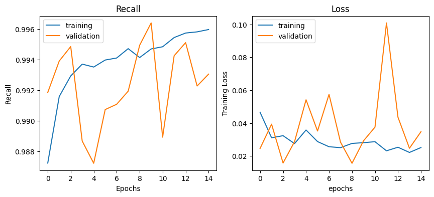

```python
plt.figure(figsize=(10,4))
plt.subplot(1,2,1)
plt.plot(history_arch2_param1['recall'], label='training')

plt.ylabel('Recall')
plt.title('Training')
plt.plot(history_arch2_param1['val_recall'], label='validation')
plt.xlabel('Epochs')
plt.title('Recall')
plt.legend()

plt.subplot(1,2,2)
plt.plot(history_arch2_param1['loss'], label='training')
plt.ylabel('Training Loss')
plt.xlabel('Epochs')

plt.plot(history_arch2_param1['val_loss'], label='validation')
plt.xlabel('epochs')
plt.title('Loss')
plt.legend()
plt.show()
```

The training loss looks like it has approximately converged, and the trend of the validation loss is approximately flat, despite the spike around epoch 11 and the large variance in the loss function.

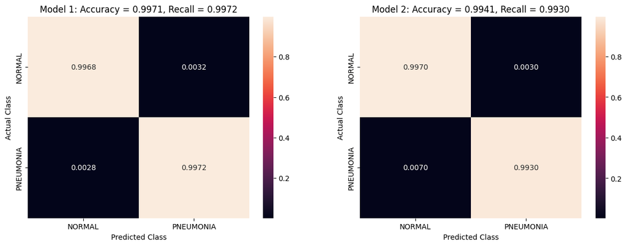

```python
compare_models(y_test, [yhat_arch1_param1, yhat_arch2_param1 ])
```

## Model 3 (Architecture 1, Parameter Set 2)

Going back to the first architecture (2 convolutional layers and no additional dense layers), we can change the number of filters in each convolutional layer from 16 to 32 to see if the results change.

```python
cnn_arch1_param2 = create_model([32, 32], (3, 3), (3, 3))

cnn_arch1_param2.summary()
```

```
Model: "sequential_2"
_________________________________________________________________
 Layer (type)                Output Shape              Param #
=================================================================
 random_brightness_2 (Rando  (None, 50, 50, 1)         0
 mBrightness)

 conv2d_5 (Conv2D)           (None, 50, 50, 32)        320

 activation_5 (Activation)   (None, 50, 50, 32)        0

 max_pooling2d_5 (MaxPoolin  (None, 16, 16, 32)        0
 g2D)

 conv2d_6 (Conv2D)           (None, 16, 16, 32)        9248

 activation_6 (Activation)   (None, 16, 16, 32)        0

 max_pooling2d_6 (MaxPoolin  (None, 5, 5, 32)          0
 g2D)

 flatten_2 (Flatten)         (None, 800)               0

 dense_4 (Dense)             (None, 1)                 801

=================================================================
Total params: 10369 (40.50 KB)
Trainable params: 10369 (40.50 KB)
Non-trainable params: 0 (0.00 Byte)
_________________________________________________________________
```

```python
plot_model(
    cnn_arch1_param2, to_file='cnn_arch1_param2.png', show_shapes=True, show_layer_names=True,
    rankdir='LR', expand_nested=False, dpi=96
)
```

[figure not shown]

```python
%%time

yhat_proba_arch1_param2_folds = []
history_arch1_param2 = {
    "recall": [],
    "val_recall": [],
    "loss": [],
    "val_loss": []
}

# Iterate through cross validation folds
for i, (train, test) in enumerate(data_split):
    # Print fold number
    sys.stderr.write('\rRepeat: {}/{}, Fold: {}/{} '.format(int(i / 10) + 1, 3, (i % 10) + 1, 10))
    sys.stderr.flush()

    # Fit model
    history = cnn_arch1_param2.fit(
        train[0],
        train[1],
        batch_size=32,
        epochs=15,
        shuffle=True,
        verbose=0,
        validation_data=(test[0], test[1])
    )

    # Store model history
    history_arch1_param2["recall"].append(history.history["recall"])
    history_arch1_param2["val_recall"].append(history.history["val_recall"])
    history_arch1_param2["loss"].append(history.history["loss"])
    history_arch1_param2["val_loss"].append(history.history["val_loss"])

    # Store model predicted probabilities
    yhat_proba_arch1_param2_folds.append(cnn_arch1_param2.predict(test[0], verbose = 0))

# Merge predicted probabilities for all folds
yhat_proba_arch1_param2 = [ prob[0] for probs in yhat_proba_arch1_param2_folds for prob in probs ]
yhat_arch1_param2 = np.round(yhat_proba_arch1_param2) # round to get binary class
yhat_arch1_param2_folds = list(map(lambda x: np.round(x)[:,0], yhat_proba_arch1_param2_folds))
# Take the mean of all history values for each epoch
for key in history_arch1_param2.keys():
    history_arch1_param2[key] = np.mean(history_arch1_param2[key], axis = 0)
```

```
Repeat: 3/3, Fold: 10/10
```

```
CPU times: user 1h 5min 24s, sys: 14min 25s, total: 1h 19min 50s
Wall time: 11min 51s
```

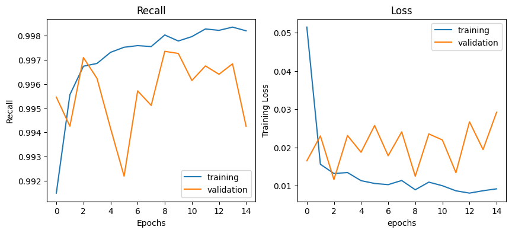

```python
plt.figure(figsize=(10,4))
plt.subplot(1,2,1)
plt.plot(history_arch1_param2['recall'], label='training')

plt.ylabel('Recall')
plt.title('Training')
plt.plot(history_arch1_param2['val_recall'], label='validation')
plt.xlabel('Epochs')
plt.title('Recall')
plt.legend()

plt.subplot(1,2,2)
plt.plot(history_arch1_param2['loss'], label='training')
plt.ylabel('Training Loss')
plt.xlabel('Epochs')

plt.plot(history_arch1_param2['val_loss'], label='validation')
plt.xlabel('epochs')
plt.title('Loss')
plt.legend()
plt.show()
```

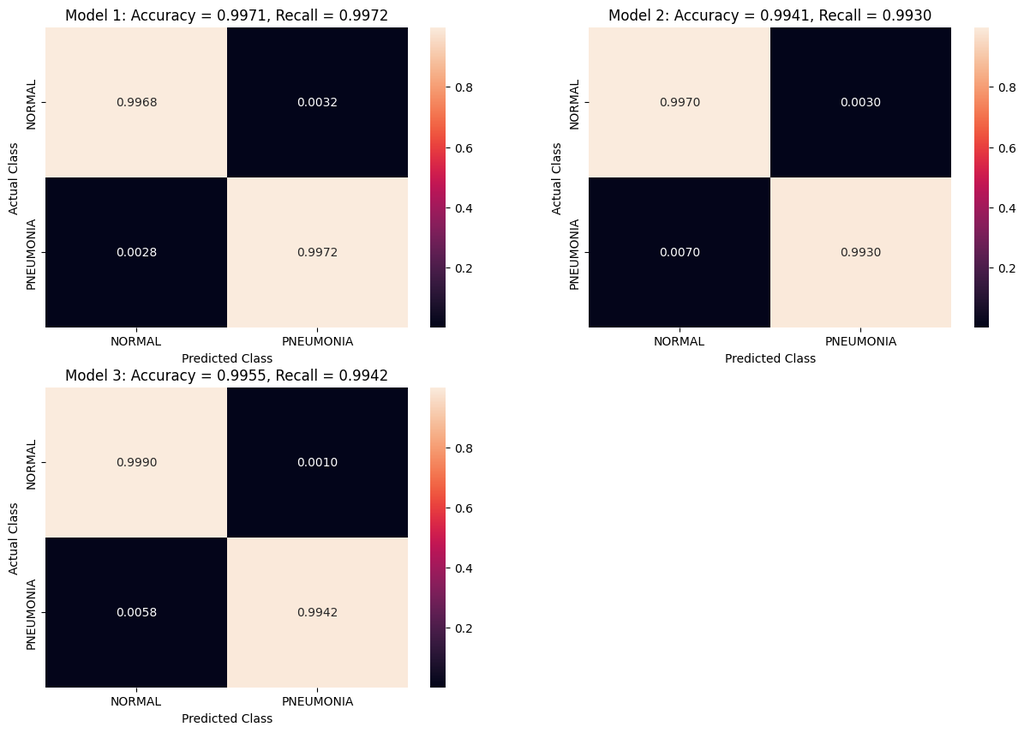

```python
compare_models(y_test, [yhat_arch1_param1, yhat_arch2_param1, yhat_arch1_param2])
```

## Model 4 (Architecture 2, Parameter Set 2)

With the second architecture (3 convolutional layers and 2 additional dense layers), we can change the number of filters in each convolutional layer from 16 to 32 and the number of dense layer neurons from 250 and 100 to 200 and 100.

```python
cnn_arch2_param2 = create_model([32, 32, 32], (3, 3), (3, 3), [200, 100])

cnn_arch2_param2.summary()
```

```
Model: "sequential_3"
_________________________________________________________________
 Layer (type)                Output Shape              Param #
=================================================================
 random_brightness_3 (Rando  (None, 50, 50, 1)         0
 mBrightness)

 conv2d_7 (Conv2D)           (None, 50, 50, 32)        320

 activation_7 (Activation)   (None, 50, 50, 32)        0

 max_pooling2d_7 (MaxPoolin  (None, 16, 16, 32)        0
 g2D)

 conv2d_8 (Conv2D)           (None, 16, 16, 32)        9248

 activation_8 (Activation)   (None, 16, 16, 32)        0

 max_pooling2d_8 (MaxPoolin  (None, 5, 5, 32)          0
 g2D)

 conv2d_9 (Conv2D)           (None, 5, 5, 32)          9248

 activation_9 (Activation)   (None, 5, 5, 32)          0

 max_pooling2d_9 (MaxPoolin  (None, 1, 1, 32)          0
 g2D)

 flatten_3 (Flatten)         (None, 32)                0

 dense_5 (Dense)             (None, 200)               6600

 dense_6 (Dense)             (None, 100)               20100

 dense_7 (Dense)             (None, 1)                 101

=================================================================
Total params: 45617 (178.19 KB)
Trainable params: 45617 (178.19 KB)
Non-trainable params: 0 (0.00 Byte)
_________________________________________________________________
```

```python
plot_model(
    cnn_arch2_param2, to_file='cnn_arch2_param2.png', show_shapes=True, show_layer_names=True,
    rankdir='LR', expand_nested=False, dpi=96
)
```

[figure not shown]

```python
%%time

yhat_proba_arch2_param2_folds = []
history_arch2_param2 = {
    "recall": [],
    "val_recall": [],
    "loss": [],
    "val_loss": []
}

# Iterate through cross validation folds
for i, (train, test) in enumerate(data_split):
    # Print fold number
    sys.stderr.write('\rRepeat: {}/{}, Fold: {}/{} '.format(int(i / 10) + 1, 3, (i % 10) + 1, 10))
    sys.stderr.flush()

    # Fit model
    history = cnn_arch2_param2.fit(
        train[0],
        train[1],
        batch_size=32,
        epochs=15,
        shuffle=True,
        verbose=0,
        validation_data=(test[0], test[1])
    )

    # Store model history
    history_arch2_param2["recall"].append(history.history["recall"])
    history_arch2_param2["val_recall"].append(history.history["val_recall"])
    history_arch2_param2["loss"].append(history.history["loss"])
    history_arch2_param2["val_loss"].append(history.history["val_loss"])

    # Store model predicted probabilities
    yhat_proba_arch2_param2_folds.append(cnn_arch2_param2.predict(test[0], verbose = 0))

# Merge predicted probabilities for all folds
yhat_proba_arch2_param2 = [ prob[0] for probs in yhat_proba_arch2_param2_folds for prob in probs ]
yhat_arch2_param2 = np.round(yhat_proba_arch2_param2) # round to get binary class
yhat_arch2_param2_folds = list(map(lambda x: np.round(x)[:,0], yhat_proba_arch2_param2_folds))
# Take the mean of all history values for each epoch
for key in history_arch2_param2.keys():
    history_arch2_param2[key] = np.mean(history_arch2_param2[key], axis = 0)
```

```
Repeat: 3/3, Fold: 10/10
```

```
CPU times: user 1h 8s, sys: 16min 11s, total: 1h 16min 20s
Wall time: 12min
```

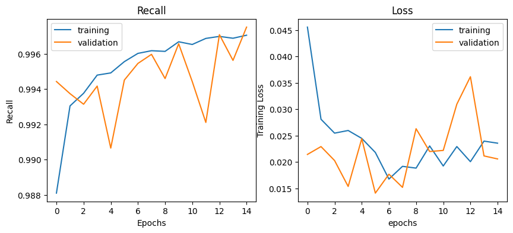

```python
plt.figure(figsize=(10,4))
plt.subplot(1,2,1)
plt.plot(history_arch2_param2['recall'], label='training')

plt.ylabel('Recall')
plt.title('Training')
plt.plot(history_arch2_param2['val_recall'], label='validation')
plt.xlabel('Epochs')
plt.title('Recall')
plt.legend()

plt.subplot(1,2,2)
plt.plot(history_arch2_param2['loss'], label='training')
plt.ylabel('Training Loss')
plt.xlabel('Epochs')

plt.plot(history_arch2_param2['val_loss'], label='validation')
plt.xlabel('epochs')
plt.title('Loss')
plt.legend()
plt.show()
```

The loss function of the training data appears to have converged, despite a dip at 6 epochs, and the trend of the validation loss function is approximately constant, despite a peak at about 12 epochs.

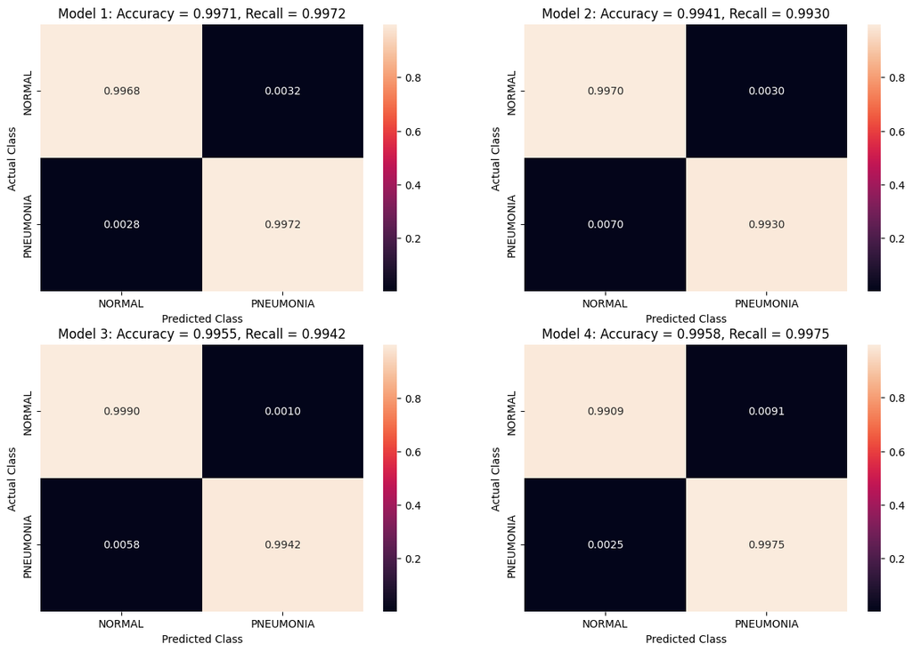

```python
compare_models(y_test, [yhat_arch1_param1, yhat_arch2_param1, yhat_arch1_param2, yhat_arch2_param2])
```

## Model Comparison

The heatmaps above show that the model accuracy and recall is fairly similar for all of the models (all scores are greater than 0.99). However, we can find a confidence interval for the mean difference in recall score for the folds between two models to determine if one model performs better than another. Since there are 30 total folds (10 folds in each of the 3 repeats), we will use a t-distribution with 29 degrees of freedom and a 95% confidence level to compute the confidence interval.

```python
# Function that returns the 95% confidence interval for folded comparison of two models
def folded_comparison(y, yhat1, yhat2, scorer):
    recall1 = np.zeros(len(y))
    recall2 = np.zeros(len(y))
    for i in range(len(y)):
        recall1[i] = scorer(y[i], yhat1[i])
        recall2[i] = scorer(y[i], yhat2[i])

    t = 2.045 / np.sqrt(len(y))
    e = recall2 - recall1
    sd = np.std(e)
    dbar = np.mean(e)

    lower = dbar - t * sd
    upper = dbar + t * sd

    return (lower, upper)
```

```python
all_fold_yhats = [
    yhat_arch1_param1_folds, yhat_arch2_param1_folds, yhat_arch1_param2_folds, yhat_arch2_param2_folds
]
for i in range(len(all_fold_yhats)):
    for j in range(i+1, len(all_fold_yhats)):
        print("Models {} and {}:".format(i+1, j+1))
        result = folded_comparison(y_test_folds, all_fold_yhats[i], all_fold_yhats[j], mt.recall_score)
        print(result)
        print()
```

```
Models 1 and 2:
(-0.006842361650567363, -0.0013953436295146083)

Models 1 and 3:
(-0.008187610418661333, 0.0023589370204864417)

Models 1 and 4:
(-0.001160568223981882, 0.0018456449472744924)

Models 2 and 3:
(-0.004115620163663571, 0.00652465204557065)

Models 2 and 4:
(0.0015178261783990554, 0.007404955824975525)

Models 3 and 4:
(-0.0029386326090193805, 0.009452382730486883)
```

```python
for i in range(len(all_fold_yhats)):
    for j in range(i+1, len(all_fold_yhats)):
        print("Models {} and {}:".format(i+1, j+1))
        result = folded_comparison(y_test_folds, all_fold_yhats[i], all_fold_yhats[j], mt.precision_score)
        print(result)
```

```
Models 1 and 2:
(-0.001612732013807062, 0.0017657463654470156)
Models 1 and 3:
(-0.0010764146064667218, 0.002629563222311912)
Models 1 and 4:
(-0.00709790737224987, 0.0031033669986056905)
Models 2 and 3:
(-0.0016509013874668747, 0.0030510356516721114)
Models 2 and 4:
(-0.006647490065963192, 0.002499935340679058)
Models 3 and 4:
(-0.008715830652425552, 0.003168141662936182)
```

## Multi-Layer Perceptron

We can compare the performance of our best CNN (model 1) to a multi-layer perceptron to see if the convolutional layers improve performance.

```python
mlp = create_model([], None, None, [250, 200, 100])

mlp.summary()
```

```
Model: "sequential_6"
_________________________________________________________________
 Layer (type)                Output Shape              Param #
=================================================================
 random_brightness_5 (Rando  (None, 50, 50, 1)         0
 mBrightness)

 flatten_5 (Flatten)         (None, 2500)              0

 dense_15 (Dense)            (None, 250)               625250

 dense_16 (Dense)            (None, 200)               50200

 dense_17 (Dense)            (None, 100)               20100

 dense_18 (Dense)            (None, 1)                 101

=================================================================
Total params: 695651 (2.65 MB)
Trainable params: 695651 (2.65 MB)
Non-trainable params: 0 (0.00 Byte)
_________________________________________________________________
```

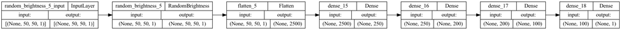

```python
plot_model(
    mlp, to_file='mlp.png', show_shapes=True, show_layer_names=True,
    rankdir='LR', expand_nested=False, dpi=96
)
```

```python
%%time

yhat_proba_mlp_folds = []
history_mlp = {
    "recall": [],
    "val_recall": [],
    "loss": [],
    "val_loss": []
}

# Iterate through cross validation folds
for i, (train, test) in enumerate(data_split):
    # Print fold number
    sys.stderr.write('\rRepeat: {}/{}, Fold: {}/{} '.format(int(i / 10) + 1, 3, (i % 10) + 1, 10))
    sys.stderr.flush()

    # Fit model
    history = mlp.fit(
        train[0],
        train[1],
        batch_size=32,
        epochs=15,
        shuffle=True,
        verbose=0,
        validation_data=(test[0], test[1])
    )

    # Store model history
    history_mlp["recall"].append(history.history["recall"])
    history_mlp["val_recall"].append(history.history["val_recall"])
    history_mlp["loss"].append(history.history["loss"])
    history_mlp["val_loss"].append(history.history["val_loss"])

    # Store model predicted probabilities
    yhat_proba_mlp_folds.append(mlp.predict(test[0], verbose = 0))

# Merge predicted probabilities for all folds
yhat_proba_mlp = [ prob[0] for probs in yhat_proba_mlp_folds for prob in probs ]
yhat_mlp = np.round(yhat_proba_mlp) # round to get binary class
yhat_mlp_folds = list(map(lambda x: np.round(x)[:,0], yhat_proba_mlp_folds))
# Take the mean of all history values for each epoch
for key in history_mlp.keys():
    history_mlp[key] = np.mean(history_mlp[key], axis = 0)
```

```
Repeat: 3/3, Fold: 10/10
```

```
CPU times: user 10min 22s, sys: 6min 17s, total: 16min 39s
Wall time: 5min 3s
```

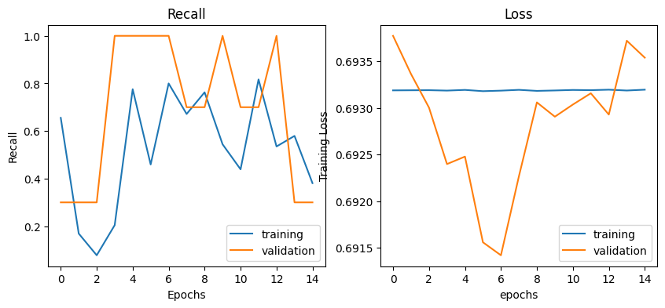

```python
plt.figure(figsize=(10,4))
plt.subplot(1,2,1)
plt.plot(history_mlp['recall'], label='training')

plt.ylabel('Recall')
plt.title('Training')
plt.plot(history_mlp['val_recall'], label='validation')
plt.xlabel('Epochs')
plt.title('Recall')
plt.legend()

plt.subplot(1,2,2)
plt.plot(history_mlp['loss'], label='training')
plt.ylabel('Training Loss')
plt.xlabel('Epochs')

plt.plot(history_mlp['val_loss'], label='validation')
plt.xlabel('epochs')
plt.title('Loss')
plt.legend()
plt.show()
```

The loss function on the training data has converged, but the loss function on the validation data has a lot of variation.

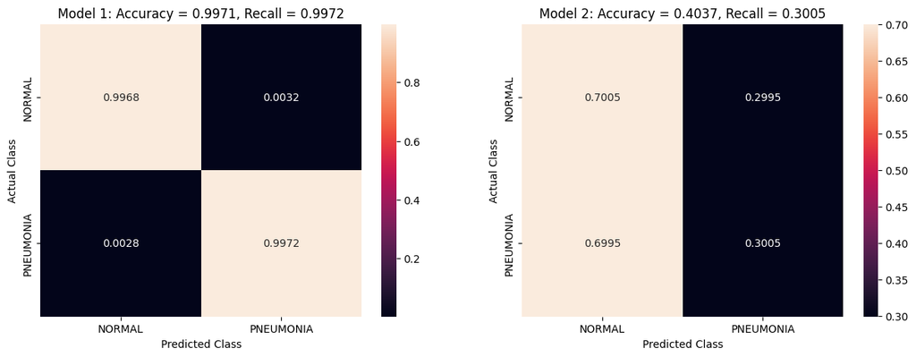

```python
compare_models(y_test, [yhat_arch1_param1, yhat_mlp])
```

```python
folded_comparison(y_test_folds, yhat_arch1_param1_folds, yhat_mlp_folds, mt.recall_score)
```

```
(-0.8689806643703973, -0.5253580665371195)
```

At the 95% confidence level, there is significant evidence that there is a differnce in the recall scores of the best CNN and the MLP. The heatmaps show that the CNN has a much higher recall score than the MLP, so we can conclude that the CNN model is better.

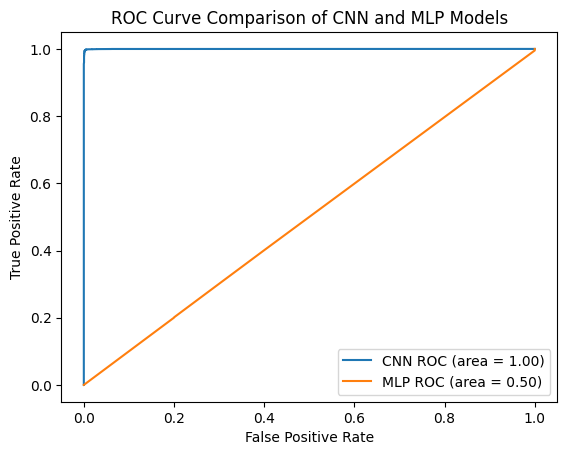

```python
# Convolutional neural network
fpr_cnn, tpr_cnn, thresholds_cnn = mt.roc_curve(
    y_test,
    yhat_proba_arch1_param1,
    pos_label=1
)
auc_cnn = mt.auc(fpr_cnn, tpr_cnn)
plt.plot(
    fpr_cnn,
    tpr_cnn,
    label='CNN ROC (area = %0.2f)' % (auc_cnn)
)

# Multi-layer perceptron
fpr_mlp, tpr_mlp, thresholds_mlp = mt.roc_curve(
    y_test,
    yhat_proba_mlp,
    pos_label=1
)
auc_mlp = mt.auc(fpr_mlp, tpr_mlp)
plt.plot(
    fpr_mlp,
    tpr_mlp,
    label='MLP ROC (area = %0.2f)' % (auc_mlp)
)

plt.xlabel("False Positive Rate")
plt.ylabel("True Positive Rate")
plt.title("ROC Curve Comparison of CNN and MLP Models")
plt.legend()
plt.show()
```

The area under the ROC curve for the CNN is much larger than the area under the curve for the MLP, which lines up with the confidence interval computed above. The ROC curve for the MLP is approximately diagonal, which suggests that the MLP has similar predictive power to choosing randomly.

## Pre-Trained Model

We can also compare our best CNN to a pre-trained model based on ResNet. We can load ResNet from Keras and remove the top of the network, so that we can modify the final few layers to match our data. We set the ResNet layers to not be trainable, so that we will use the pre-trained weights computed on the imagenet dataset.

```python
resnet = ResNet50(
    weights = "imagenet",
    include_top = False,
    input_shape = (h, w, 3),
    pooling = "max"
)

resnet.trainable = False

resnet.summary()
```

```
Model: "resnet50"
__________________________________________________________________________________________________
 Layer (type)                Output Shape                 Param #   Connected to
==================================================================================================
 input_1 (InputLayer)        [(None, 50, 50, 3)]          0         []

 conv1_pad (ZeroPadding2D)   (None, 56, 56, 3)            0         ['input_1[0][0]']

 conv1_conv (Conv2D)         (None, 25, 25, 64)           9472      ['conv1_pad[0][0]']

 conv1_bn (BatchNormalizati  (None, 25, 25, 64)           256       ['conv1_conv[0][0]']
 on)

 conv1_relu (Activation)     (None, 25, 25, 64)           0         ['conv1_bn[0][0]']

 pool1_pad (ZeroPadding2D)   (None, 27, 27, 64)           0         ['conv1_relu[0][0]']

 pool1_pool (MaxPooling2D)   (None, 13, 13, 64)           0         ['pool1_pad[0][0]']

 conv2_block1_1_conv (Conv2  (None, 13, 13, 64)           4160      ['pool1_pool[0][0]']
 D)

 conv2_block1_1_bn (BatchNo  (None, 13, 13, 64)           256       ['conv2_block1_1_conv[0][0]']
 rmalization)

 conv2_block1_1_relu (Activ  (None, 13, 13, 64)           0         ['conv2_block1_1_bn[0][0]']
 ation)

 conv2_block1_2_conv (Conv2  (None, 13, 13, 64)           36928     ['conv2_block1_1_relu[0][0]']
 D)

 conv2_block1_2_bn (BatchNo  (None, 13, 13, 64)           256       ['conv2_block1_2_conv[0][0]']
 rmalization)

 conv2_block1_2_relu (Activ  (None, 13, 13, 64)           0         ['conv2_block1_2_bn[0][0]']
 ation)

 conv2_block1_0_conv (Conv2  (None, 13, 13, 256)          16640     ['pool1_pool[0][0]']
 D)

```

[output cut: 476 more lines]

```

 conv5_block3_add (Add)      (None, 2, 2, 2048)           0         ['conv5_block2_out[0][0]',
                                                                     'conv5_block3_3_bn[0][0]']

 conv5_block3_out (Activati  (None, 2, 2, 2048)           0         ['conv5_block3_add[0][0]']
 on)

 max_pool (GlobalMaxPooling  (None, 2048)                 0         ['conv5_block3_out[0][0]']
 2D)

==================================================================================================
Total params: 23587712 (89.98 MB)
Trainable params: 0 (0.00 Byte)
Non-trainable params: 23587712 (89.98 MB)
__________________________________________________________________________________________________
```

ResNet expects images with 3 channels as inputs, so we will ad a convolutional layer with 3 filters to the beginning of the network to add the required channels to our images. We will then send the convolved images into the pre-trained ResNet network and end with 2 dense layers. The first layer has 10 neurons with a relu activation and the final layer has 1 neuron with a sigmoid activation to make our binary classification.

```python
pretrained = Sequential()

pretrained.add(
    Conv2D(
        filters=3,
        kernel_size=(3,3),
        padding='same',
    )
)

pretrained.add(resnet)
pretrained.add(Dense(10, activation = "relu"))
pretrained.add(Dense(1, activation = "sigmoid"))

# Let's train the model
pretrained.compile(
    loss='binary_crossentropy',
    optimizer='rmsprop',
    metrics=[Recall(name = "recall")]
)

input_shape = [None, h, w, 1]
pretrained.build(input_shape)

pretrained.summary()
```

```
Model: "sequential_5"
_________________________________________________________________
 Layer (type)                Output Shape              Param #
=================================================================
 conv2d_10 (Conv2D)          (None, 50, 50, 3)         30

 resnet50 (Functional)       (None, 2048)              23587712

 dense_13 (Dense)            (None, 10)                20490

 dense_14 (Dense)            (None, 1)                 11

=================================================================
Total params: 23608243 (90.06 MB)
Trainable params: 20531 (80.20 KB)
Non-trainable params: 23587712 (89.98 MB)
_________________________________________________________________
```

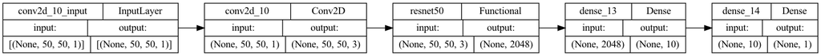

```python
plot_model(
    pretrained, to_file='pretrained.png', show_shapes=True, show_layer_names=True,
    rankdir='LR', expand_nested=False, dpi=96
)
```

```python
%%time

yhat_proba_pretrained_folds = []
history_pretrained = {
    "recall": [],
    "val_recall": [],
    "loss": [],
    "val_loss": []
}

# Iterate through cross validation folds
for i, (train, test) in enumerate(data_split):
    # Print fold number
    sys.stderr.write('\rRepeat: {}/{}, Fold: {}/{} '.format(int(i / 10) + 1, 3, (i % 10) + 1, 10))
    sys.stderr.flush()

    # Fit model
    history = pretrained.fit(
        train[0],
        train[1],
        batch_size=32,
        epochs=5,
        shuffle=True,
        verbose=0,
        validation_data=(test[0], test[1])
    )

    # Store model history
    history_pretrained["recall"].append(history.history["recall"])
    history_pretrained["val_recall"].append(history.history["val_recall"])
    history_pretrained["loss"].append(history.history["loss"])
    history_pretrained["val_loss"].append(history.history["val_loss"])

    # Store model predicted probabilities
    yhat_proba_pretrained_folds.append(pretrained.predict(test[0], verbose = 0))

# Merge predicted probabilities for all folds
yhat_proba_pretrained = [ prob[0] for probs in yhat_proba_pretrained_folds for prob in probs ]
yhat_pretrained = np.round(yhat_proba_pretrained) # round to get binary class
yhat_pretrained_folds = list(map(lambda x: np.round(x)[:,0], yhat_proba_pretrained_folds))
# Take the mean of all history values for each epoch
for key in history_pretrained.keys():
    history_pretrained[key] = np.mean(history_pretrained[key], axis = 0)
```

```
Repeat: 3/3, Fold: 10/10
```

```
CPU times: user 9h 25min 23s, sys: 3h 11min 33s, total: 12h 36min 57s
Wall time: 2h 37min 58s
```

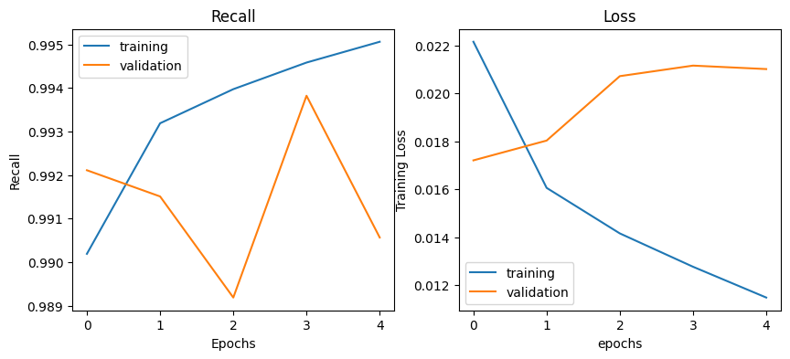

```python
plt.figure(figsize=(10,4))
plt.subplot(1,2,1)
plt.plot(history_pretrained['recall'], label='training')

plt.ylabel('Recall')
plt.title('Training')
plt.plot(history_pretrained['val_recall'], label='validation')
plt.xlabel('Epochs')
plt.title('Recall')
plt.legend()

plt.subplot(1,2,2)
plt.plot(history_pretrained['loss'], label='training')
plt.ylabel('Training Loss')
plt.xlabel('Epochs')

plt.plot(history_pretrained['val_loss'], label='validation')
plt.xlabel('epochs')
plt.title('Loss')
plt.legend()
plt.show()
```

The ResNet network significantly increases the training time, so the network was only trained with 5 epochs for this lab. It is difficult to tell with if the model has converged or not with only 5 epochs. With more time, I would experiment with more epochs to find the best number of epochs before deploying a model.

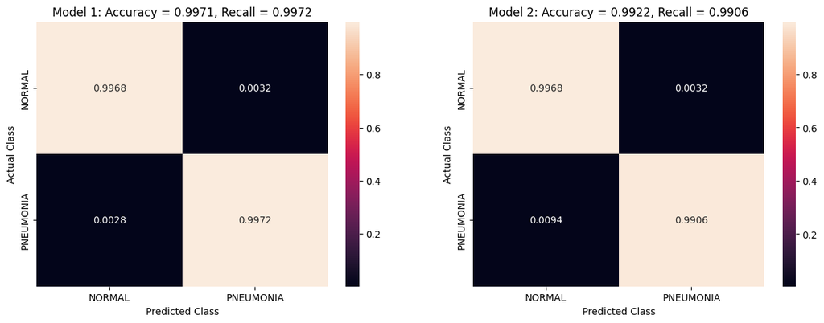

```python
compare_models(y_test, [yhat_arch1_param1, yhat_pretrained])
```

```python
folded_comparison(y_test_folds, yhat_arch1_param1_folds, yhat_pretrained_folds, mt.recall_score)
```

```
(-0.014413703090398794, 0.0012108479415017265)
```

At the 95% confidence level, there is not a significant difference in the recall scores of the best CNN and the pre-trained ResNet model.